# The Human-Wolf Simulation … Fitted!

[Population Ecology - EFB 370](https://eligurarie.github.io/EFB370)

Problem Set

### Due date: Friday, March 6, 2026, 11:59 pm.

### Total Points: **15**

> *Instructions:* *Submit this homework as a document. It can be entirely typed on a computer and uploaded on Blackboard, or completed as a combination of handwritten and printed (computer generated plots must be printed). Answer questions in complete sentences and explain how you obtained your answers. Only provide answers and include plots, do* **NOT** *send in code! Collaboration and discussion - openly and on the discussion forum - is highly encouraged, but do not provide and publicize actual answers.*

In this assignment, you will fit the **logistic growth curve** to data on the human-wolf-simulation we collected last week, using the tools we practiced in the [Lab](https://eligurarie.github.io/EFB370/labs/labII.3/FittingLogisticGrowth.html).

Here’s a plot of all the data:

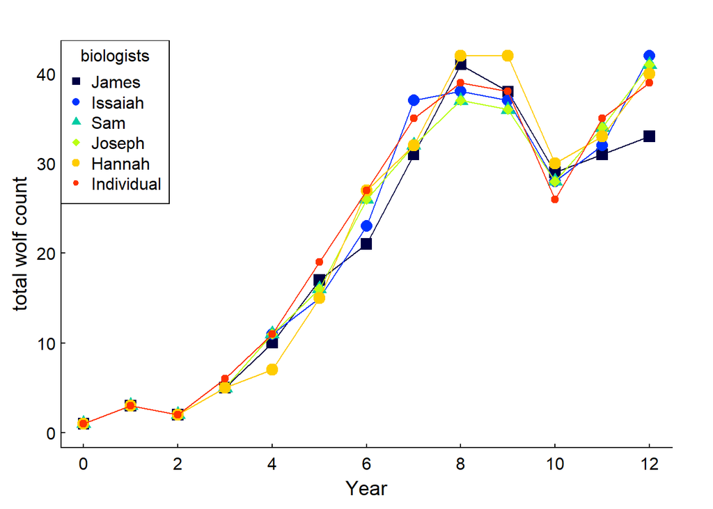

### 1. (**1 pts**)

Load the dataset, and select **one** of the six sets of observations. Plot that curve, and comment on its shape, i.e. does it look (a) linear, (b) exponential, (c) sigmoidal or something else?

### 2. (**2 pts**)

Fit a logistic curve to the data “by hand”, i.e. using the logistic function we used in Part I of the lab. Report your best guess for $N_0$, $r_0$ and $K$. Plot the fitted curve on the data in blue .

### 3. (**3 pts**)

Fit a logistic curve to the data using non-linear least squares. Report the *point estimates* and *95% Confidence Intervals* of the three parameters. Plot the fitted curve on the data. Make the curve red .

### 4. (**3 pts**)

You know everything about the population ecology of this system. Does your analysis suggest there is **density dependence** in this system? If so, does it act on **birth rates** or **death rates** or both? Explain in detail!

### 5. (**2 pts**)

For both births and deaths, specify (a) whether stochasticity plays a role, (b) if yes, whether it is *demographic* or *environmental*.

### 6. (**2 pts**)

Would you characterize the growth of this population as *logistic*? Do you think the *functional form* of the dependence of population growth rate on abundance is *linear*, *convex*, or *concave*?

### EXTRA CREDIT

Assess your assessment in Question 6 graphically.

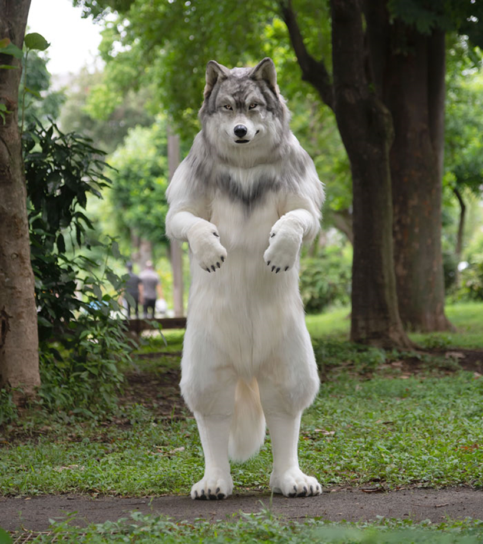

**This is a very well-fitted human-wolf simulation.**